# lab3: Data wrangling with tidyverse

Soc 225: Data & Society

2024-01-21

```r
## Run this code, to manage packages and install as needed.
# Install pacman
if (!require("pacman")) install.packages("pacman", repos = "http://cran.us.r-project.org")
# p_load function loads packages if installed, or install then loads otherwise
pacman::p_load(tidyverse,ggtheme)
```

# Agenda

- Introduction and setup
- Modify data frames
- Summarize data frames
- Create new variables
- Data visualization - basics
  - Histograms
  - Bar charts

# 1. Introduction and setup

We will be looking at what cell tracking data can tell us about covid-19 exposure in today’s lab through managing and summarizing data. The data set we use today contains indices describing possible exposure to covid-19 on the basis of anonymous cell phone movement data produced by [Place IQ](https://www.placeiq.com). The main index we look at will be state-level device exposure index (DEX). According to the authors who developed this index:

- State-level device exposure index (DEX): For a smartphone residing in a given state, how many distinct devices also visited any of the commercial venues that this device visited today? The state-level DEX reports the state-level average of this number across all devices residing in the state that day.
  - DEX-income reports the state-level average of this number for the four groups of devices residing in each of four neighborhood-income quantiles. For DEX indices by census-block-group income quantile, 1 indexes the poorest quantile, and 4 the richest.

To get a complete view of the project of deriving the above exposure indices from PlaceIQ data, visit [Measuring movement and social contact with smartphone data: a real-time application to COVID-19](https://github.com/COVIDExposureIndices/COVIDExposureIndices) by Couture et al. 2021.

To wrangle data in R, there are two main dialects: one is to use base R, and the other is to use package `tidyverse`. Many people mix the two. We will be using a more pure `tidyverse` style in this lab.

As a first step, we will setup the package and data.

**Question 1.1: load package tidyverse and read data “data/state_dex_cleaned.csv”, assign the object name “state_dex”.**

```r
state_dex<-read_csv("data/state_dex_cleaned.csv")
```

We can get a glimpse of object `state_dex` by running the below command:

```r
glimpse(state_dex)
```

```
## Rows: 4,590
## Columns: 12
## $ state                <chr> "AK", "AK", "AK", "AK", "AK", "AK", "AK", "AK", "…
## $ date                 <date> 2020-02-01, 2020-02-02, 2020-02-03, 2020-02-04, …
## $ dex                  <dbl> 117.4519, 54.6235, 83.5664, 87.4964, 95.9697, 102…
## $ num_devices          <dbl> 29335, 28977, 30301, 30963, 31844, 31465, 31625, …
## $ dex_income_1         <dbl> 141.0878, 70.4200, 100.8198, 97.1956, 126.9906, 1…
## $ num_devices_income_1 <dbl> 1093, 1069, 1110, 1135, 1172, 1127, 1145, 1111, 1…
## $ dex_income_2         <dbl> 110.3145, 52.8559, 82.6956, 90.1460, 97.5252, 96.…
## $ num_devices_income_2 <dbl> 4836, 4748, 4958, 5083, 5263, 5115, 5228, 5090, 5…
## $ dex_income_3         <dbl> 115.6567, 51.9067, 81.0161, 81.0339, 92.4149, 99.…
## $ num_devices_income_3 <dbl> 10015, 9908, 10357, 10569, 10873, 10817, 10775, 1…
## $ dex_income_4         <dbl> 120.3371, 53.9964, 84.6124, 90.4721, 96.7948, 106…
## $ num_devices_income_4 <dbl> 12452, 12371, 12942, 13220, 13600, 13490, 13514, …
```

**Question 1.2. How many rows do you get in this data frame? What does each row represent?**

**Question 1.3. What are the possible bias of measuring device exposure by restricting venues to commercial locations? Do you think DEX might overestimate or underestimate the exposure?**

# 2. Modify data frame

This section introduces key `dplyr` verbs to modify a data frame.

**Pipe** The core package in `tidyverse` to manipulate data is `dplyr`. It is loaded in R’s memory when we loaded `tidyverse` earlier. `dplyr` uses the `magrittr` forward pipe operator, usually called simply a **pipe**. We write pipes like `%>%` (`Ctrl+Shift+M`, or `CMD+Shift+M` on Mac). Pipes take the object on the *left* and apply the function on the *right*: `x %>% f(y) = f(x,y)`. An example is shown below:

```r
state_dex %>%
  filter(state == "PA") %>% # create a subset of data
  head(5)
```

```
## # A tibble: 5 × 12
##   state date         dex num_devices dex_income_1 num_devices_income_1
##   <chr> <date>     <dbl>       <dbl>        <dbl>                <dbl>
## 1 PA    2020-02-01  218.      717059         201.               110465
## 2 PA    2020-02-02  112.      715386         109.               110287
## 3 PA    2020-02-03  146.      743874         175.               115786
## 4 PA    2020-02-04  152.      756702         175.               117587
## 5 PA    2020-02-05  156.      758098         180.               117807
## # ℹ 6 more variables: dex_income_2 <dbl>, num_devices_income_2 <dbl>,
## #   dex_income_3 <dbl>, num_devices_income_3 <dbl>, dex_income_4 <dbl>,
## #   num_devices_income_4 <dbl>
```

Pipes save us typing, make code readable, and allow chaining like above, so we use them *all the time* when manipulating data frames.

**Pipe Assignment** When creating a new object from the output of piped functions, place the assignment operator at the beginning (you can do assignment at the end of the chain as well):

```r
PA_dex <- state_dex %>%
  filter(state == "PA")
```

**Question 2.1. Use the pipe to show the last 20 rows of the data frame.**

**filter()** choose rows (observations) by some characteristics

```r
state_dex %>%
  filter(date>"2020-03-01") %>%
  head(5)
```

```
## # A tibble: 5 × 12
##   state date         dex num_devices dex_income_1 num_devices_income_1
##   <chr> <date>     <dbl>       <dbl>        <dbl>                <dbl>
## 1 AK    2020-03-02  75.1       27132         79.6                 1008
## 2 AK    2020-03-03  81.6       27503         83.9                  977
## 3 AK    2020-03-04  86.3       27418         90.1                 1034
## 4 AK    2020-03-05  88.4       27408        113.                  1035
## 5 AK    2020-03-06 111.        27420        124.                  1031
## # ℹ 6 more variables: dex_income_2 <dbl>, num_devices_income_2 <dbl>,
## #   dex_income_3 <dbl>, num_devices_income_3 <dbl>, dex_income_4 <dbl>,
## #   num_devices_income_4 <dbl>
```

**operator %in%** filter rows to things in some *set*.

**select()** choose columns (variables) by name

```r
state_dex %>%
  select(state,date,dex) %>%
  head(5)
```

```
## # A tibble: 5 × 3
##   state date         dex
##   <chr> <date>     <dbl>
## 1 AK    2020-02-01 117.
## 2 AK    2020-02-02  54.6
## 3 AK    2020-02-03  83.6
## 4 AK    2020-02-04  87.5
## 5 AK    2020-02-05  96.0
```

We can also drop only specific columns with select() using `-` signs.

```r
state_dex %>%
  select(-num_devices_income_1,-num_devices_income_2)
```

```
## # A tibble: 4,590 × 10
##    state date         dex num_devices dex_income_1 dex_income_2 dex_income_3
##    <chr> <date>     <dbl>       <dbl>        <dbl>        <dbl>        <dbl>
##  1 AK    2020-02-01 117.        29335        141.         110.         116.
##  2 AK    2020-02-02  54.6       28977         70.4         52.9         51.9
##  3 AK    2020-02-03  83.6       30301        101.          82.7         81.0
##  4 AK    2020-02-04  87.5       30963         97.2         90.1         81.0
##  5 AK    2020-02-05  96.0       31844        127.          97.5         92.4
##  6 AK    2020-02-06 102.        31465        131.          96.9         99.3
##  7 AK    2020-02-07 130.        31625        143.         124.         125.
##  8 AK    2020-02-08 114.        30816        119.         107.         111.
##  9 AK    2020-02-09  82.6       30635         95.7         79.4         77.9
## 10 AK    2020-02-10  96.0       32162        113.          94.2         92.4
## # ℹ 4,580 more rows
## # ℹ 3 more variables: num_devices_income_3 <dbl>, dex_income_4 <dbl>,
## #   num_devices_income_4 <dbl>
```

**Question 2.2. Use select to show only the state, date and dex variables.**

**Logical operators**

```r
state_dex %>%
  filter(state=="AK")
```

```
## # A tibble: 90 × 12
##    state date         dex num_devices dex_income_1 num_devices_income_1
##    <chr> <date>     <dbl>       <dbl>        <dbl>                <dbl>
##  1 AK    2020-02-01 117.        29335        141.                  1093
##  2 AK    2020-02-02  54.6       28977         70.4                 1069
##  3 AK    2020-02-03  83.6       30301        101.                  1110
##  4 AK    2020-02-04  87.5       30963         97.2                 1135
##  5 AK    2020-02-05  96.0       31844        127.                  1172
##  6 AK    2020-02-06 102.        31465        131.                  1127
##  7 AK    2020-02-07 130.        31625        143.                  1145
##  8 AK    2020-02-08 114.        30816        119.                  1111
##  9 AK    2020-02-09  82.6       30635         95.7                 1085
## 10 AK    2020-02-10  96.0       32162        113.                  1192
## # ℹ 80 more rows
## # ℹ 6 more variables: dex_income_2 <dbl>, num_devices_income_2 <dbl>,
## #   dex_income_3 <dbl>, num_devices_income_3 <dbl>, dex_income_4 <dbl>,
## #   num_devices_income_4 <dbl>
```

What does `state=="AK` actually do?

```r
head(state_dex$state=="AK",100)
```

```
##   [1]  TRUE  TRUE  TRUE  TRUE  TRUE  TRUE  TRUE  TRUE  TRUE  TRUE  TRUE  TRUE
##  [13]  TRUE  TRUE  TRUE  TRUE  TRUE  TRUE  TRUE  TRUE  TRUE  TRUE  TRUE  TRUE
##  [25]  TRUE  TRUE  TRUE  TRUE  TRUE  TRUE  TRUE  TRUE  TRUE  TRUE  TRUE  TRUE
##  [37]  TRUE  TRUE  TRUE  TRUE  TRUE  TRUE  TRUE  TRUE  TRUE  TRUE  TRUE  TRUE
##  [49]  TRUE  TRUE  TRUE  TRUE  TRUE  TRUE  TRUE  TRUE  TRUE  TRUE  TRUE  TRUE
##  [61]  TRUE  TRUE  TRUE  TRUE  TRUE  TRUE  TRUE  TRUE  TRUE  TRUE  TRUE  TRUE
##  [73]  TRUE  TRUE  TRUE  TRUE  TRUE  TRUE  TRUE  TRUE  TRUE  TRUE  TRUE  TRUE
##  [85]  TRUE  TRUE  TRUE  TRUE  TRUE  TRUE FALSE FALSE FALSE FALSE FALSE FALSE
##  [97] FALSE FALSE FALSE FALSE
```

It returns a vector of `TRUE` or `FALSE` values. When used for subset, elements for which a `TRUE` is given are returned, while those corresponding to `FALSE` are dropped. We used `==` for testing “equals”.

There are many other *logical operators*: - `!=`: not equal to - `>`,`>=`,`<`,`<=`: less than, less than or equal to, etc. - `%in%`: used with checking equal to one of several values

Or we can combine multiple logical conditions: - `&`: both conditions need to hold (AND) - `|`: at least one condition needs to hold (OR) - `!`: inverts a logical condition (`TRUE` becomes `FALSE`, `FALSE` becomes `TRUE`)

**Question 2.3. Create a subset of state_dex by only look at dex for Texas. This new data frame contains the following variables only: state, date, dex, dex_income_1, dex_income_2, dex_income_3, dex_income_4. Name this object “TX_dex”.**

**Question 2.4. Create a set of states containing Washington, Oregon and California. Find observations in state_dex that only belong to this set of states. How many rows do you get?**

**arrange** put data in order by one or more variables.

```r
state_dex %>%
  arrange(state, desc(dex))
```

```
## # A tibble: 4,590 × 12
##    state date         dex num_devices dex_income_1 num_devices_income_1
##    <chr> <date>     <dbl>       <dbl>        <dbl>                <dbl>
##  1 AK    2020-02-14  150.       31541         207.                 1129
##  2 AK    2020-02-28  135.       31920         156.                 1221
##  3 AK    2020-02-07  130.       31625         143.                 1145
##  4 AK    2020-02-22  122.       31436         127.                 1119
##  5 AK    2020-02-21  120.       32540         139.                 1155
##  6 AK    2020-02-01  117.       29335         141.                 1093
##  7 AK    2020-02-15  116.       30843         133.                 1161
##  8 AK    2020-02-08  114.       30816         119.                 1111
##  9 AK    2020-02-29  112.       29290         134.                 1045
## 10 AK    2020-03-06  111.       27420         124.                 1031
## # ℹ 4,580 more rows
## # ℹ 6 more variables: dex_income_2 <dbl>, num_devices_income_2 <dbl>,
## #   dex_income_3 <dbl>, num_devices_income_3 <dbl>, dex_income_4 <dbl>,
## #   num_devices_income_4 <dbl>
```

The data are sorted by ascending `state` and descending `dex`.

**Question 2.5. Now go back to TX_dex data. Find ten days in February 2020 with the highest dex, and name this object TX_Feb. Do the same for April 2020 and name this object TX_Apr. Take a look at TX_Feb and TX_Apr. What do you observe?** (Check hints if you have troubles)

# 3. Summarize data frames

**summarize()** takes your column(s) of data and computes something using every row:

- count how many rows there are
- calculate the mean
- compute the sum
- Obtain a minimum or maximum value.

You can use any function in summarize() that aggregates *multiple values* into to a *single value* (like sd(), mean(), or max()).

```r
state_dex %>%
  filter(date<"2020-03-01") %>%
  summarize(n_obs = n(),
            mean_dex = mean(dex),
            range_dex = max(dex)-min(dex))
```

```
## # A tibble: 1 × 3
##   n_obs mean_dex range_dex
##   <int>    <dbl>     <dbl>
## 1  1479     157.     1076.
```

**Question 3.1. Calculate the standard deviation of dex in Pennsylvania.**

**group_by** the special function `group_by()` changes how functions operate on the data, most importantly `summarize()`.

Functions after `group_by` are computed *within* each group as defined by variables given, rather than over all rows at once. Typically the variables you group by will be integers, factors, or characters, and not continuous real values.

```r
state_dex %>%
  group_by(state) %>%
  summarize(mean_dex=mean(dex))
```

```
## # A tibble: 51 × 2
##    state mean_dex
##    <chr>    <dbl>
##  1 AK        68.2
##  2 AL       127.
##  3 AR       120.
##  4 AZ       102.
##  5 CA        84.8
##  6 CO        71.3
##  7 CT        67.7
##  8 DC       106.
##  9 DE        91.3
## 10 FL       165.
## # ℹ 41 more rows
```

**Question 3.2. On March 15, 2020, what is the difference between dex of the richest neighborhood and dex of the poorest neighborhood for each state?** (Check hints if you have troubles)

**Question 3.3. On April 1, 2020, what is the average dex number of the following states: MA, NY, PA?**

**Question 3.4. In March, for all states except for Alaska and Hawaii, what is the lowest dex? Which date and state does it associate with?**

# 4. Create new variables

**mutate** you can add new columns to a data frame using `mutate()`.

```r
state_dex %>%
  filter(state=="DC") %>%
  mutate(devices_thousand=num_devices/1000,
         mean_dex = mean(dex))
```

```
## # A tibble: 90 × 14
##    state date         dex num_devices dex_income_1 num_devices_income_1
##    <chr> <date>     <dbl>       <dbl>        <dbl>                <dbl>
##  1 DC    2020-02-01  193.       24988        166.                  5481
##  2 DC    2020-02-02  109.       23732         92.9                 5387
##  3 DC    2020-02-03  187.       29780        144.                  5994
##  4 DC    2020-02-04  206.       31920        154.                  6158
##  5 DC    2020-02-05  204.       31053        167.                  6062
##  6 DC    2020-02-06  208.       31381        160.                  5919
##  7 DC    2020-02-07  225.       30634        170.                  5867
##  8 DC    2020-02-08  192.       25881        172.                  5487
##  9 DC    2020-02-09  122.       24407         98.7                 5316
## 10 DC    2020-02-10  182.       30984        136.                  6014
## # ℹ 80 more rows
## # ℹ 8 more variables: dex_income_2 <dbl>, num_devices_income_2 <dbl>,
## #   dex_income_3 <dbl>, num_devices_income_3 <dbl>, dex_income_4 <dbl>,
## #   num_devices_income_4 <dbl>, devices_thousand <dbl>, mean_dex <dbl>
```

**Question 4.1. Take a look at the above code. What is the difference between using `summarize` and `mutate` to calculate group mean?**

**ifelse()** A common function used in `mutate()` (and in general R programming) is ifelse(). It returns a vector of values depending on a logical test. For example:

```r
example <- c(1,0,NA,-2)
ifelse(example>0, "Positive","Not positive")
```

```
## [1] "Positive"     "Not positive" NA             "Not positive"
```

```r
state_dex %>%
  mutate(full_state_name =
           ifelse(state=="AK","Alaska",
                  as.character(state))) %>%
        select(state,date,dex,full_state_name) %>%
        distinct(full_state_name)
```

```
## # A tibble: 51 × 1
##    full_state_name
##    <chr>
##  1 Alaska
##  2 AL
##  3 AR
##  4 AZ
##  5 CA
##  6 CO
##  7 CT
##  8 DC
##  9 DE
## 10 FL
## # ℹ 41 more rows
```

**distinct** allows us to see all the *unique values* in our data for one or combinations of columns.

**Question 4.2. For each state, what is the mean dex for each month?** (Check hints if you have troubles)

**Question 4.3. Which states have the highest mean dex in February, March and April respectively?**

# 5. Basics of data visualization

Now that we can adjust what data we’re looking at with some verbs, we can start making visualizations. Not only do these look cool, but they’re a great way to get a sense for big patterns in your data.

We’ll start by plotting a single variable, using bar charts and histograms. To do so, we need to install and load the `ggplot2` package. In the next lab, we will learn how to use `ggplot2` in detail.

**Question 5.1. Install and load the `ggplot2` package.**

## Histograms

What’s the distribution of dex of Washington state? We can see this using a histogram. Histograms are for *continuous* or numeric values.

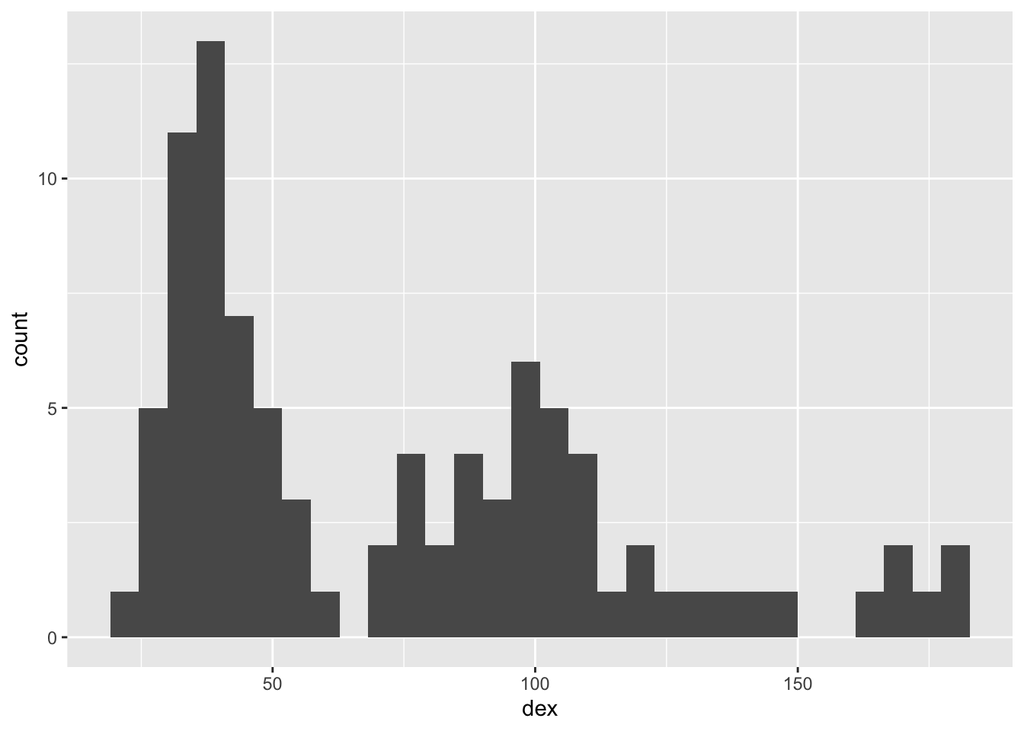

```r
state_dex %>%
  filter(state=="WA") %>% # filter for state WA
  ggplot(aes(x = dex)) + # start a plot and set the aesthetics with the x axis dex
  geom_histogram() # make a histogram
```

**Question 5.2: Make a histogram of dex of a state you are interested in. How is the dex distributed differently in February, March and April? Do you think histogram is a good way of plotting changes with time?**

## Bar charts

Now we look at how dex differ in different states by counting how many days do different states have a dex of higher than 45. Bar charts are for *categorical* values.

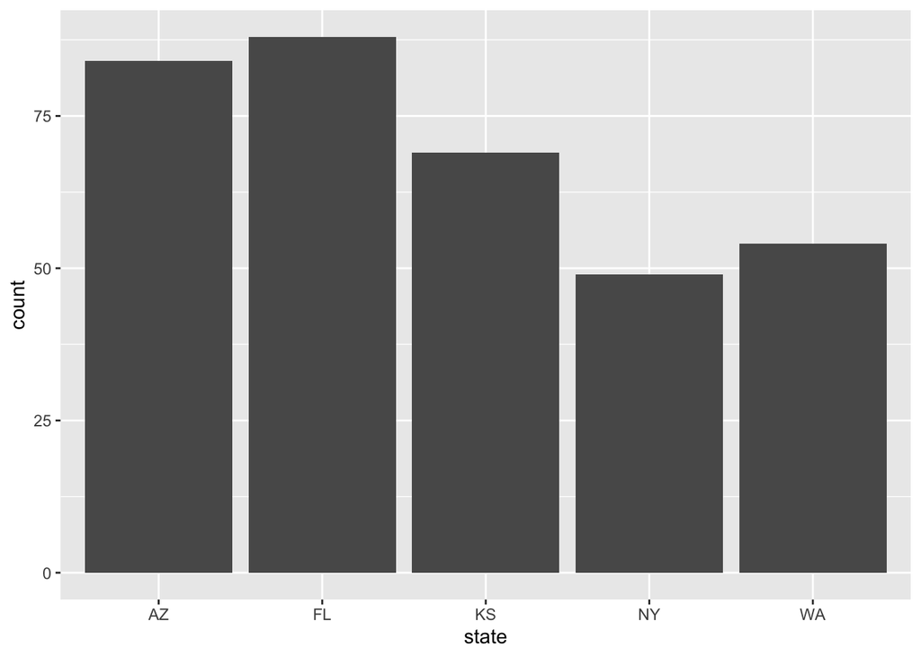

```r
state_dex %>% # take state_dex data
  filter(state%in%(c("WA","KS","FL","AZ","NY")) & dex>45) %>% # filter by state and dex
  ggplot(aes(x=state)) + # start a plot and set the aesthetics with the x axis the selected states
  geom_bar() # make a bar chart
```

It’s a good idea to give every plot a *title*, to tell people what it’s about.

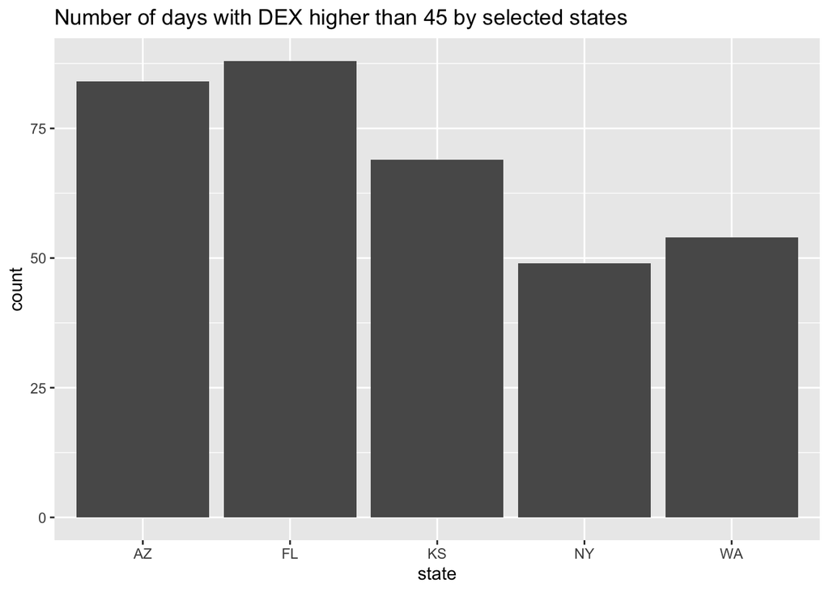

```r
state_dex %>% # take state_dex data
  filter(state%in%(c("WA","KS","FL","AZ","NY")) & dex>45) %>%
  ggplot(aes(x=state)) + # start a plot and set the aesthetics with the x axis the selected states
  geom_bar() + # make a bar chart
  labs(title = "Number of days with DEX higher than 45 by selected states")
```

**Question 5.3. Make a bar chart comparing the count of days of which dex is higher than 60 by states of your choice. Is there a difference if you compare dex of the poorest neighborhood and of the richest neighborhood? Why do you think is the difference?**

# Just for fun: ggplot themes

The gray theme is the default, but ggplot has a variety of themes you can use. For example, someone may like the minimal theme better (`theme_minimal`). Type `?theme_gray` for a list.

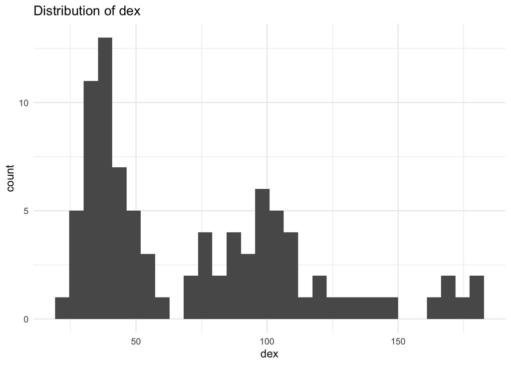

```r
state_dex %>%
  filter(state=="WA") %>% # filter for state WA
  ggplot(aes(x = dex)) + # start a plot and set the aesthetics with the x axis dex
  geom_histogram() +
  theme_minimal() +
  labs(title = "Distribution of dex",
       x = "dex")
```

```r
# for even more fun themes:
# install.packages("ggthemes")
# library(ggthemes)
# state_dex %>%
#   filter(state=="WA) %>%
#   ggplot(aes(x = dex)) +
#   geom_histogram() +
#   theme_wsj()
```

Hints

2.5. Use the `&` operator to apply multiple filters 3.2. Use `==` operator to check for exactly equal 4.2. There are multiple ways to extract month from date format. Try install and load package `lubridate` and learn from the Help file on how to do it. Your answer should contain 153 rows, i.e. three rows for each state.

# References

Cuture, Victor, Jonathan I. Dingel, Allison Green, Jessie Handbury, and Kevin R. Williams. 2021. “JUE Insight: Measuring Movement and Social Contact with Smartphone Data: A Real-Time Application to COVID-19.” Journal of Urban Economics 103328. doi: 10.1016/j.jue.2021.103328.

Charles Lanfear, [Introduction to R for Social Scientists](https://clanfear.github.io/CSSS508/)